# Reproducible Reasearch Peer Assessment 1

Keith Linhares

Wednesday, May 06, 2015

**Loading and Preprocessing the Data**

```r
activity <- read.csv("activity.csv")
```

1. What is mean total number of steps taken per day? Below gives a total of steps per day

```r
stepsbyday <- aggregate(steps ~ date, data = activity, sum)
stepsbyday
```

```
##          date steps
## 1  2012-10-02   126
## 2  2012-10-03 11352
## 3  2012-10-04 12116
## 4  2012-10-05 13294
## 5  2012-10-06 15420
## 6  2012-10-07 11015
## 7  2012-10-09 12811
## 8  2012-10-10  9900
## 9  2012-10-11 10304
## 10 2012-10-12 17382
## 11 2012-10-13 12426
## 12 2012-10-14 15098
## 13 2012-10-15 10139
## 14 2012-10-16 15084
```

[output cut: 39 more lines]

2. If you do not understand the difference between a histogram and a barplot, research the difference between them. Make a histogram of the total number of steps taken each day.

Below is a histogram of the Steps by Day:

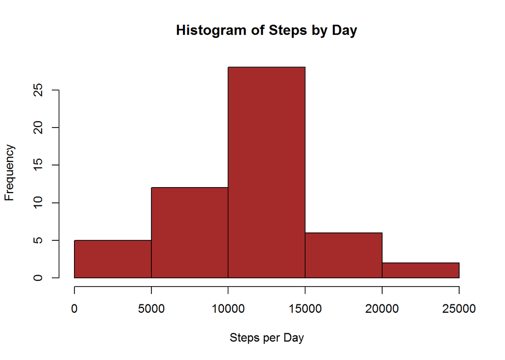

```r
hist(stepsbyday$steps, main = "Histogram of Steps by Day", xlab = "Steps per Day", col = "brown")
```

3. Calculate and report the mean and median of the total number of steps taken per day

```r
mean(stepsbyday$steps)
```

```
## [1] 10766.19
```

```r
median(stepsbyday$steps)
```

```
## [1] 10765
```

**What is the average daily activity pattern?**

1. Make a time series plot (i.e. type = “l”) of the 5-minute interval (x-axis) and the average number of steps taken, averaged across all days (y-axis).

First, I need to aggregate steps by interval:

```r
stepsbyinterval <- aggregate(steps~interval, data = activity, mean)
```

Next, I will make the plot:

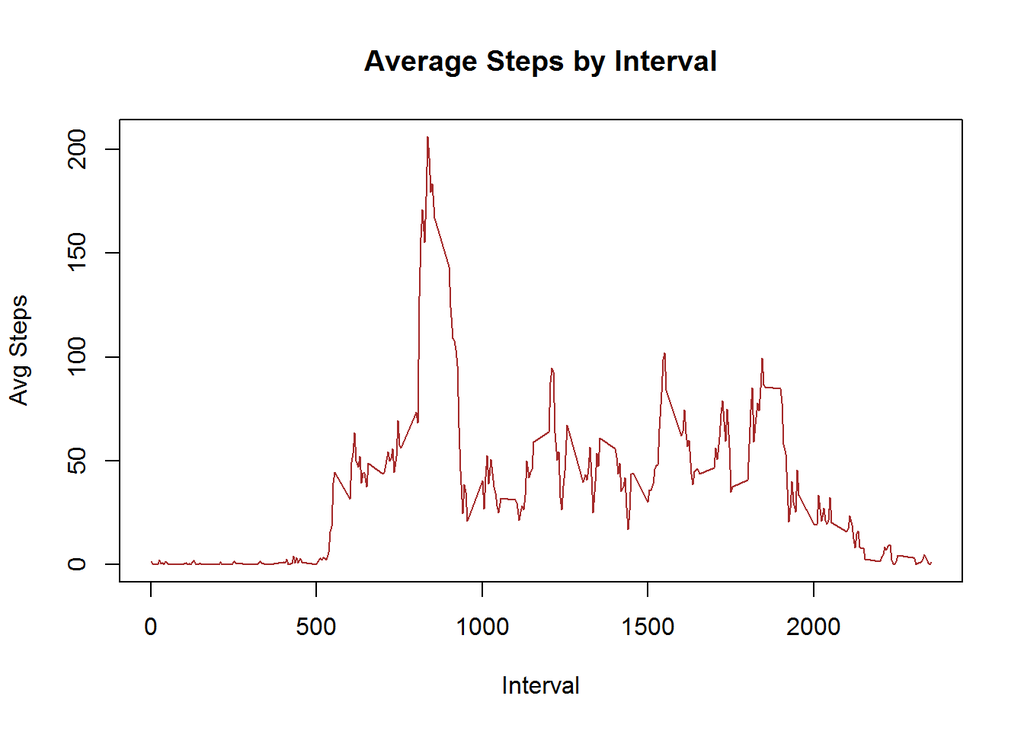

```r
plot(stepsbyinterval,type = "l", main = "Average Steps by Interval", xlab = "Interval", ylab = "Avg Steps", col = "brown")
```

2. Which 5-minute interval, on average across all the days in the dataset, contains the maximum number of steps?

Determine the max of my “stepsbyinterval” data frame. I am going to check what the max is, then filter for the max using dplyr to find the row

```r
max(stepsbyinterval$steps)
```

```
## [1] 206.1698
```

```r
library(dplyr)
filter(stepsbyinterval, steps >= 206.1698)
```

```
##   interval    steps
## 1      835 206.1698
```

**Imputing missing values**

1. Calculate and report the total number of missing values in the dataset (i.e. the total number of rows with NAs)

```r
sum(is.na(activity))
```

```
## [1] 2304
```

2. Devise a strategy for filling in all of the missing values in the dataset. The strategy does not need to be sophisticated. For example, you could use the mean/median for that day, or the mean for that 5-minute interval, etc.

I already have stepsbyinterval, so I will use that to replace the data in activity with the mean of interval.

I was having trouble with the for loop, so I used some pieces from the website below:

http://rstudio-pubs-static.s3.amazonaws.com/17469_4fbb71c305ba4a25a40eba1f8cdbb3e9.html